# PA1_template

PH

Wednesday, April 15, 2015

https://github.com/Xiaodan/RepData_PeerAssessment1/blob/master/PA1_template.md

### Loading and preprocessing the data

```r
unzip("repdata-data-activity.zip")
data<- read.csv("activity.csv", colClasses = c("integer", "Date", "factor"))
data$month <- as.numeric(format(data$date, "%m"))
omitNA <- na.omit(data)
rownames(omitNA) <- 1:nrow(omitNA)
head(omitNA)
```

```
##   steps       date interval month
## 1     0 2012-10-02        0    10
## 2     0 2012-10-02        5    10
## 3     0 2012-10-02       10    10
## 4     0 2012-10-02       15    10
## 5     0 2012-10-02       20    10
## 6     0 2012-10-02       25    10
```

### What is mean total number of steps taken per day?

Make a histogram of the total number of steps taken each day

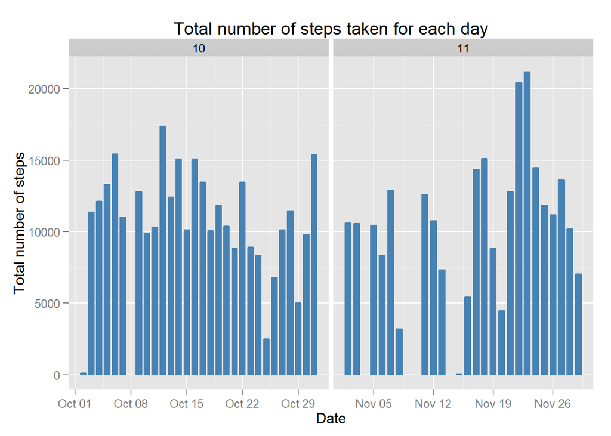

```r
library(ggplot2)
ggplot(omitNA, aes(date, steps)) + geom_bar(stat = "identity", colour = "steelblue", fill = "steelblue", width = 0.7) + facet_grid(. ~ month, scales = "free") + labs(title = "Total number of steps taken for each day", x = "Date", y = "Total number of steps")
```

Calculate and report the mean and median total number of steps taken per day

Mean

```r
total<- aggregate(omitNA$steps, list(Date = omitNA$date), FUN = "sum")$x
mean(total)
```

```
## [1] 10766.19
```

Median

```r
median(total)
```

```
## [1] 10765
```

### What is the average daily activity pattern?

Make a time series plot (i.e. type = “l”) of the 5-minute interval (x-axis) and the average number of steps taken, averaged across all days (y-axis)

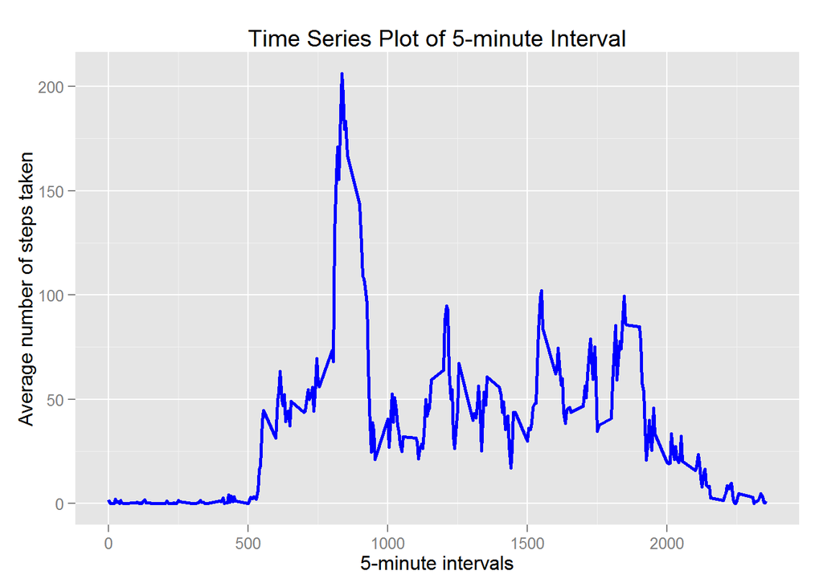

```r
AvSteps <- aggregate(omitNA$steps, list(interval = as.numeric(as.character(omitNA$interval))), FUN = "mean")
names(AvSteps)[2] <- "MeanSteps"

ggplot(AvSteps, aes(interval, MeanSteps)) + geom_line(color="blue", size =1) + labs(title = "Time Series Plot of 5-minute Interval", x = "5-minute intervals", y = "Average number of steps taken")
```

Which 5-minute interval, on average across all the days in the dataset, contains the maximum number of steps?

```r
AvSteps[AvSteps$MeanSteps == max(AvSteps$MeanSteps), ]
```

```
##     interval MeanSteps
## 104      835  206.1698
```

### Imputing missing values

Calculate and report the total number of missing values in the dataset (i.e. the total number of rows with NAs)

```r
sum(is.na(data))
```

```
## [1] 2304
```

Devise a strategy for filling in all of the missing values in the dataset. The strategy does not need to be sophisticated. For example, you could use the mean/median for that day, or the mean for that 5-minute interval, etc.

```r
data2<- data
for (i in 1:nrow(data2)) {
    if (is.na(data2$steps[i])) {
        data2$steps[i] <- AvSteps[which(data2$interval[i] == AvSteps$interval), ]$MeanSteps
    }
}

head(data2)
```

```
##       steps       date interval month
## 1 1.7169811 2012-10-01        0    10
## 2 0.3396226 2012-10-01        5    10
## 3 0.1320755 2012-10-01       10    10
## 4 0.1509434 2012-10-01       15    10
## 5 0.0754717 2012-10-01       20    10
## 6 2.0943396 2012-10-01       25    10
```

Make a histogram of the total number of steps taken each day

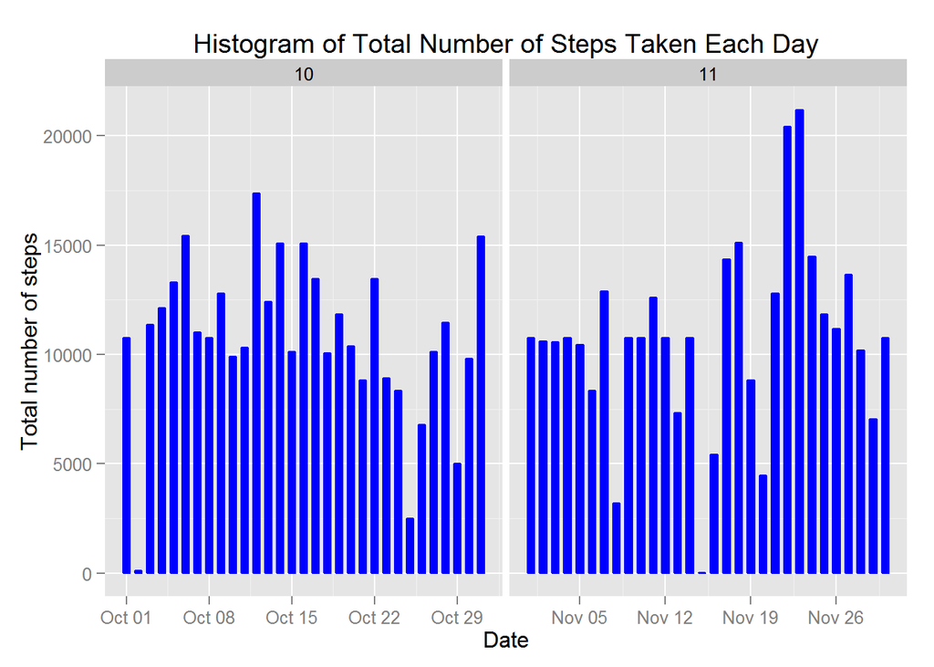

```r
ggplot(data2, aes(date, steps)) + geom_bar(stat = "identity",
                                             colour = "blue",
                                             fill = "blue",
                                             width = 0.6) + facet_grid(. ~ month, scales = "free") + labs(title = "Histogram of Total Number of Steps Taken Each Day", x = "Date", y = "Total number of steps")
```

Calculate and report the mean and median total number of steps taken per day. Do these values differ from the estimates from the first part of the assignment? What is the impact of imputing missing data on the estimates of the total daily number of steps?

New mean

```r
NewTotalSteps <- aggregate(data2$steps,
                           list(Date = data2$date),
                           FUN = "sum")$x
NewMean <- mean(NewTotalSteps)
NewMean
```

```
## [1] 10766.19
```

New Median

```r
NewMedian <- median(NewTotalSteps)
NewMedian
```

```
## [1] 10766.19
```

The mean remains the same while the median increases by 1.19